# Car Commute Analysis

## Point Plot

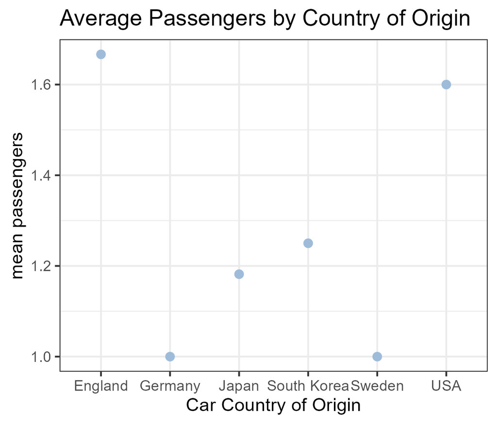

This point plot displays the average number of passengers per country of origin for each car. It seems the English speaking countries, England and USA, carry on average more passengers, they might make bigger cars on average (Land Rover, Ford). In contrast, Sweden and Germany have the fewest passengers on average.

## Violin Plot

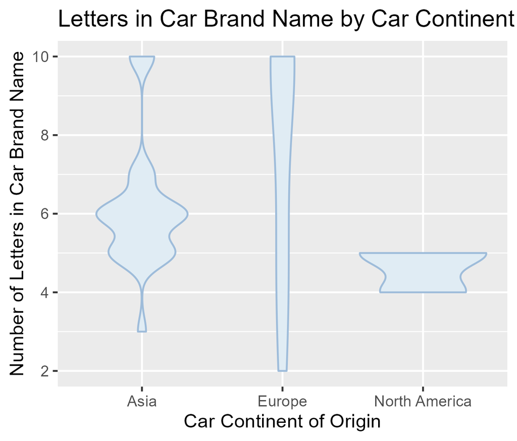

This plot indicates the number of letters in car brand names for each continent. It appears that Europe has a wide range of name lengths, and Asia also somewhat shares this trait. However, North America have much shorter names only being around the 4-5 length mark (these would be Tesla and Ford).

## Count Plot

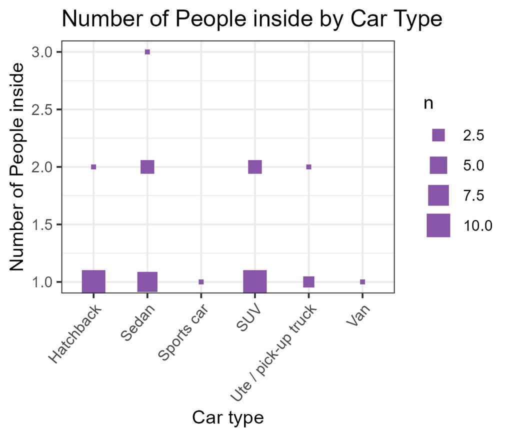

This plot shows the number of passengers by type of car. Whilst I had assumed that larger cars like pickups and SUVs would have more passengers than all the rest, it seems that from the cars I observed, sedans had a similar amount of 1 passenger and 2 passenger cars, with SUVs, but the only reported car with 3 passengers was a sedan. Also note that hatchbacks mostly had 1 passenger, and the only reported van had 1 passenger too.